# STAT 240 Discussion 9 SOLUTIONS

## Problems

The questions in this discussion assignment use the chimpanzee data set. In answering these questions, you may assume the following in models for the data:

1. all trials are independent
2. trials made with a partner have the same chance of being pro-social, even if the identities of the actors or partners differ.

### Problem 1

#### A

Using the chimpanzee data, combine all of the trials made without a partner. Count the number of pro-social and selfish choices made.

> SOLUTION

```r
chimps = read_csv("../../data/chimpanzee.csv")

prob1 = chimps %>%
  filter(partner == "none") %>%
  summarize(prosocial = sum(prosocial),
            selfish = sum(selfish),
            n = prosocial + selfish)

prob1
```

```
## # A tibble: 1 × 3
##   prosocial selfish     n
##       <dbl>   <dbl> <dbl>
## 1        83      97   180
```

#### B

Write a model for the number of pro-social choices.

> SOLUTION

$X$ is the number of pro-social choices made without a partner. $p$ is the probability of making the pro-social choice without a partner present.
$$X \sim \operatorname{Binomial}(n, p)$$
Observed data is $x=83$ and $n=180$.

#### C

Use the Agresti-Coull method to construct a 95% confidence interval for the probability that a chimpanzee makes the pro-social choice in experimental conditions when there is no partner present.

> SOLUTION

```r
x = 83
n = 180
ptilde = (x+2)/(n+4)
se = sqrt(ptilde*(1-ptilde)/(n+4))
z = qnorm(0.975)
ci = ptilde + c(-1,1)*z*se
ci
```

```
## [1] 0.3899207 0.5339923
```

```r
### or
prob1b = prob1 %>%
  mutate(ptilde = (prosocial + 2)/(n+4),
         se = sqrt(ptilde*(1-ptilde)/(n+4)),
         z = qnorm(0.975),
         ci_low = ptilde - z*se,
         ci_high = ptilde + z*se)

prob1b
```

```
## # A tibble: 1 × 8
##   prosocial selfish     n ptilde     se     z ci_low ci_high
##       <dbl>   <dbl> <dbl>  <dbl>  <dbl> <dbl>  <dbl>   <dbl>
## 1        83      97   180  0.462 0.0368  1.96  0.390   0.534
```

#### D

Interpret this confidence interval in the context of the experimental setting.

> SOLUTION

> We are 95% confident that chimpanzees make the pro-social choice with no partner present in the experimental conditions between 39.0 and 53.4 percent of the time.

### Problem 2

Using the same data as in the previous problem, do the following.

#### A

State hypotheses for a two-sided hypothesis test that the probability that a chimpanzee makes the pro-social choice over the long run is equal to 0.5 versus the alternative that this probability is not 0.5.

> SOLUTION

$$\begin{aligned}
&H_0: p=0.5 \\
&H_a: p \neq 0.5
\end{aligned}$$

#### B

Pick a test statistic, state the sampling distribution of this statistic if the null hypothesis is true, and compute a p-value for the test.

> SOLUTION

```r
x = prob1 %>% pull(prosocial)
n = prob1 %>% pull(n)

p0 = dbinom(x, n, 0.5)

prob2b = tibble(
  x = 0:n,
  prob = dbinom(x, n, 0.5)) %>%
  filter(prob < p0 | near(prob, p0))

p_value = prob2b %>%
  summarize(p_value = sum(prob)) %>%
  pull(p_value)

p_value
```

```
## [1] 0.3325791
```

#### C

Interpret these results in the context of the experiment following the examples from lecture notes.

> SOLUTION

The observed data is consistent with the null hypothesis that chimpanzees make the pro-social choice $50 \%$ of the time with no partner present ( $p=0.33$, two-sided binomial test).

### 3

Use functions from the file `ggprob.R` to visualize the calculation of the p-value by graphing an appropriate probability distribution and using differential coloring to indicate what in the plot corresponds to the p-value. Include a title and meaningful axis labels.

> SOLUTION

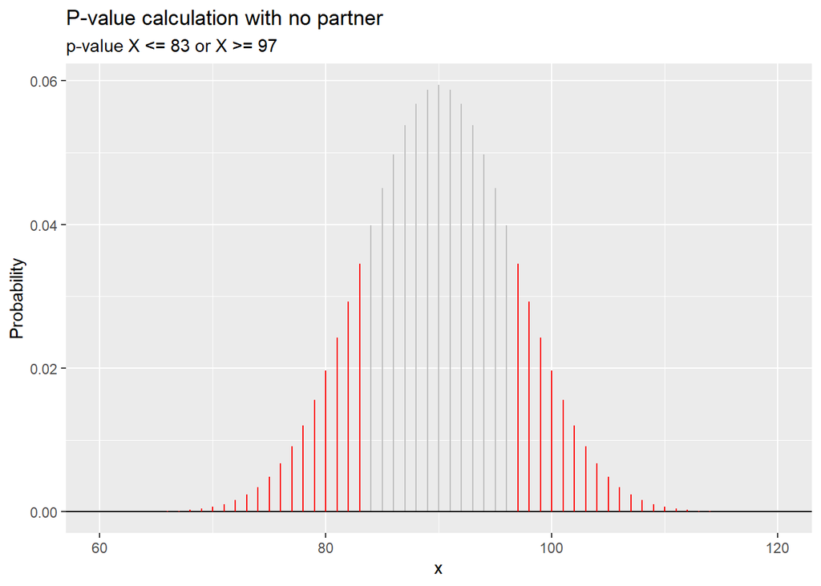

```r
gbinom(n, 0.5, scale = TRUE, color = "gray") +
  geom_binom_density(n, 0.5, color = "red", a = 60, b = 83) +
  geom_binom_density(n, 0.5, color = "red", a = 180 - 83, b = 120) +
  ggtitle("P-value calculation with no partner",
          subtitle = "p-value X <= 83 or X >= 97")
```